# Laboratorio 1. Series de tiempo

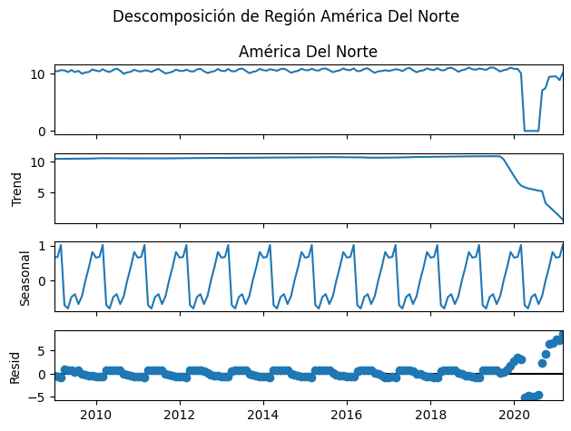

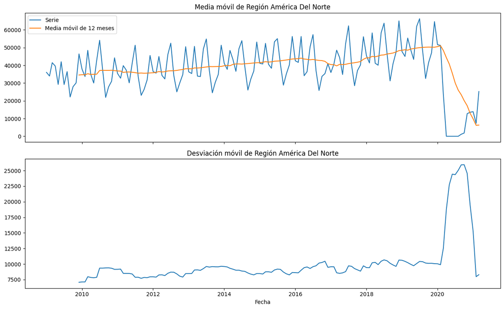

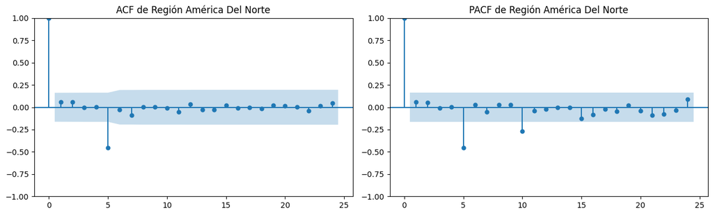

```
Inicio: 2009-01
Fin: 2026-06
Frecuencia: mensual con doce observaciones por año
Fuerza estacional: 0.113
Fuerza de tendencia: 0.142
Lambda Box Cox: 0.931
Valor sugerido de d: 1
Valor sugerido de D: 0
Valor inicial de p: 1
Valor inicial de q: 1
```

|  | Transformación | p valor ADF | Conclusión |
| --- | --- | --- | --- |
| 0 | Original | 0.010 | Estacionaria en media |
| 1 | Logaritmo | 0.158 | No estacionaria en media |
| 2 | Primera diferencia | 0.049 | Estacionaria en media |
| 3 | Diferencia estacional | 0.939 | No estacionaria en media |
| 4 | Primera diferencia y diferencia estacional | 0.000 | Estacionaria en media |

[output not shown]

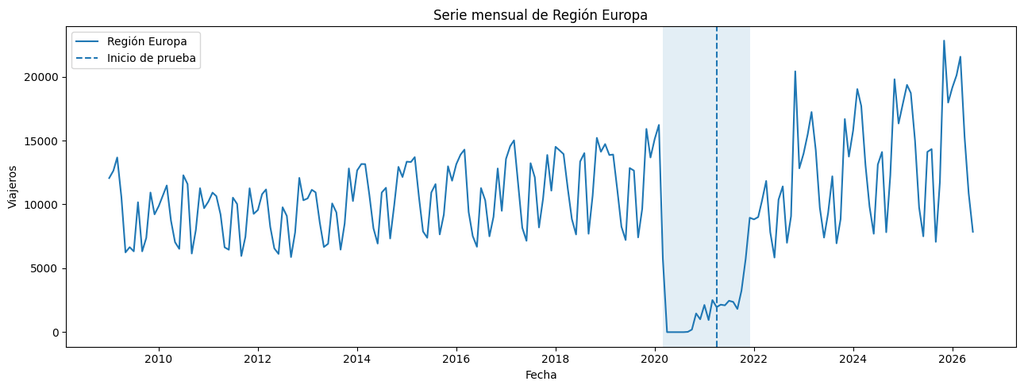

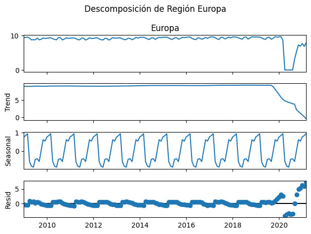

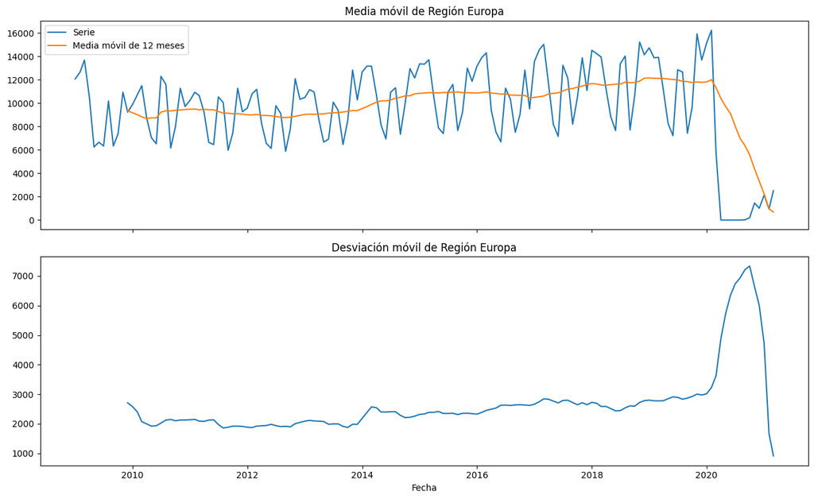

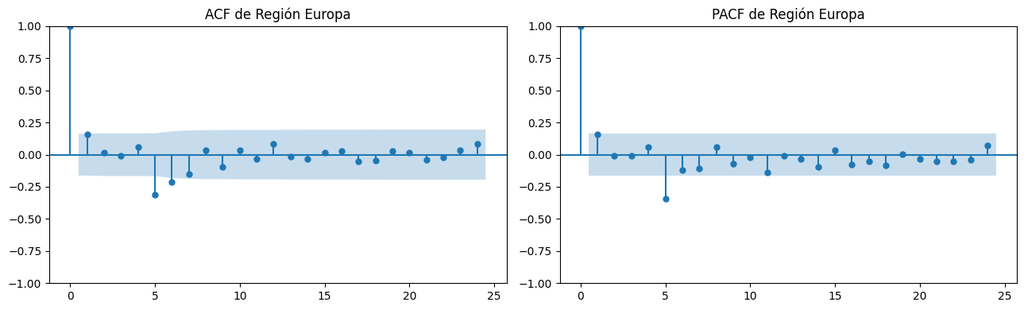

```
Inicio: 2009-01
Fin: 2026-06
Frecuencia: mensual con doce observaciones por año
Fuerza estacional: 0.176
Fuerza de tendencia: 0.316
Lambda Box Cox: 0.963
Valor sugerido de d: 1
Valor sugerido de D: 0
Valor inicial de p: 1
Valor inicial de q: 1
```

|  | Transformación | p valor ADF | Conclusión |
| --- | --- | --- | --- |
| 0 | Original | 0.122 | No estacionaria en media |
| 1 | Logaritmo | 0.285 | No estacionaria en media |
| 2 | Primera diferencia | 0.114 | No estacionaria en media |
| 3 | Diferencia estacional | 0.002 | Estacionaria en media |
| 4 | Primera diferencia y diferencia estacional | 0.000 | Estacionaria en media |

```
La serie no es estacionaria en media y necesita diferenciación.
La estacionalidad es débil y se probarán modelos con menor parte estacional.
```

| Serie | Fuerza estacional | Fuerza de tendencia | Lambda Box Cox | ADF original | ADF log | p sugerido | d sugerido | q sugerido | D sugerido |
| --- | --- | --- | --- | --- | --- | --- | --- | --- | --- |
| Total | 0.180 | 0.532 | 0.991 | 0.152 | 0.116 | 1 | 1 | 1 | 0 |
| Vía Aérea | 0.142 | 0.259 | 1.257 | 0.151 | 0.273 | 1 | 1 | 1 | 0 |
| Vía Terrestre | 0.185 | 0.714 | 0.761 | 0.238 | 0.277 | 1 | 1 | 1 | 0 |
| Vía Marítima | 0.073 | 0.972 | 0.269 | 0.847 | 0.832 | 1 | 1 | 1 | 0 |
| Región América Del Centro | 0.180 | 0.578 | 0.816 | 0.213 | 0.200 | 2 | 1 | 2 | 0 |
| Región América Del Norte | 0.113 | 0.142 | 0.931 | 0.010 | 0.158 | 1 | 1 | 1 | 0 |
| Región Europa | 0.176 | 0.316 | 0.963 | 0.122 | 0.285 | 1 | 1 | 1 | 0 |

# Modelos de pronóstico

Para cada serie se comparan varios modelos SARIMA, Holt Winters, suavizamiento exponencial simple, seasonal naive y Prophet.

Los modelos SARIMA trabajan con el logaritmo de la serie. Sus predicciones se regresan a la escala original antes de calcular los errores.

El mejor SARIMA se selecciona con AIC y BIC. El mejor modelo general se selecciona principalmente con RMSE y se revisa también el MAE.

```
==========================================================================================
Total
==========================================================================================
Comparación de modelos SARIMA
```

|  | Modelo | MAE | RMSE | AIC | BIC |
| --- | --- | --- | --- | --- | --- |
| 0 | SARIMA (0, 1, 1) x (1, 0, 0, 12) | 197,448.997 | 209,747.887 | 77.161 | 85.854 |
| 1 | SARIMA (1, 1, 1) x (1, 0, 0, 12) | 196,817.166 | 209,111.679 | 79.460 | 91.021 |
| 2 | SARIMA (1, 1, 1) x (0, 0, 1, 12) | 162,379.980 | 175,899.616 | 88.639 | 100.170 |
| 3 | SARIMA (2, 1, 1) x (0, 0, 1, 12) | 164,587.054 | 178,225.217 | 90.185 | 104.599 |
| 4 | SARIMA (1, 1, 2) x (0, 0, 1, 12) | 164,381.044 | 178,042.912 | 90.775 | 105.151 |

```
22:20:30 - cmdstanpy - INFO - Chain [1] start processing
22:20:30 - cmdstanpy - INFO - Chain [1] done processing
```

```
Comparación general
```

|  | Modelo | MAE | RMSE | AIC | BIC |
| --- | --- | --- | --- | --- | --- |
| 0 | Prophet | 132,304.568 | 139,548.877 | NaN | NaN |
| 1 | SARIMA (1, 1, 1) x (0, 0, 1, 12) | 162,379.980 | 175,899.616 | 88.639 | 100.170 |
| 2 | SARIMA (1, 1, 2) x (0, 0, 1, 12) | 164,381.044 | 178,042.912 | 90.775 | 105.151 |
| 3 | SARIMA (2, 1, 1) x (0, 0, 1, 12) | 164,587.054 | 178,225.217 | 90.185 | 104.599 |
| 4 | Suavizamiento exponencial simple | 165,372.541 | 180,598.233 | NaN | NaN |
| 5 | SARIMA (1, 1, 1) x (1, 0, 0, 12) | 196,817.166 | 209,111.679 | 79.460 | 91.021 |
| 6 | SARIMA (0, 1, 1) x (1, 0, 0, 12) | 197,448.997 | 209,747.887 | 77.161 | 85.854 |
| 7 | Seasonal naive | 207,321.637 | 219,663.869 | NaN | NaN |
| 8 | Holt Winters | 224,794.346 | 241,513.187 | NaN | NaN |

```
Mejor SARIMA según AIC y BIC: SARIMA (0, 1, 1) x (1, 0, 0, 12)
Mejor modelo según RMSE: Prophet
```

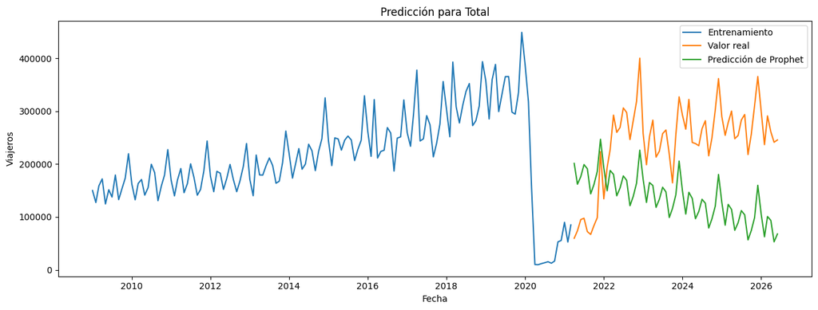

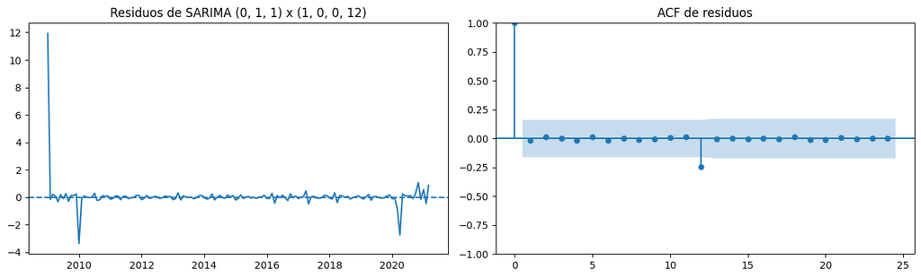

|  | lb_stat | lb_pvalue |
| --- | --- | --- |
| 12 | 9.907 | 0.624 |

```
No se detecta autocorrelación importante en los residuos al nivel de cinco por ciento.
==========================================================================================
Vía Aérea
==========================================================================================
Comparación de modelos SARIMA
```

|  | Modelo | MAE | RMSE | AIC | BIC |
| --- | --- | --- | --- | --- | --- |
| 0 | SARIMA (0, 1, 1) x (1, 0, 0, 12) | 42,873.544 | 48,869.671 | 196.900 | 205.593 |
| 1 | SARIMA (1, 1, 1) x (1, 0, 0, 12) | 41,537.954 | 47,551.610 | 198.038 | 209.600 |
| 2 | SARIMA (1, 1, 1) x (0, 0, 1, 12) | 31,483.389 | 36,548.987 | 200.544 | 212.075 |
| 3 | SARIMA (1, 1, 2) x (0, 0, 1, 12) | 34,563.152 | 39,465.243 | 201.446 | 215.822 |
| 4 | SARIMA (2, 1, 1) x (0, 0, 1, 12) | 35,296.482 | 40,166.118 | 201.677 | 216.091 |

```
22:20:31 - cmdstanpy - INFO - Chain [1] start processing
22:20:32 - cmdstanpy - INFO - Chain [1] done processing
```

```
Comparación general
```

|  | Modelo | MAE | RMSE | AIC | BIC |
| --- | --- | --- | --- | --- | --- |
| 0 | SARIMA (1, 1, 1) x (0, 0, 1, 12) | 31,483.389 | 36,548.987 | 200.544 | 212.075 |
| 1 | SARIMA (1, 1, 2) x (0, 0, 1, 12) | 34,563.152 | 39,465.243 | 201.446 | 215.822 |
| 2 | SARIMA (2, 1, 1) x (0, 0, 1, 12) | 35,296.482 | 40,166.118 | 201.677 | 216.091 |
| 3 | Suavizamiento exponencial simple | 36,970.596 | 42,141.220 | NaN | NaN |
| 4 | Prophet | 41,300.514 | 45,687.741 | NaN | NaN |
| 5 | SARIMA (1, 1, 1) x (1, 0, 0, 12) | 41,537.954 | 47,551.610 | 198.038 | 209.600 |
| 6 | SARIMA (0, 1, 1) x (1, 0, 0, 12) | 42,873.544 | 48,869.671 | 196.900 | 205.593 |
| 7 | Holt Winters | 59,525.620 | 64,260.307 | NaN | NaN |
| 8 | Seasonal naive | 75,512.726 | 79,339.803 | NaN | NaN |

```
Mejor SARIMA según AIC y BIC: SARIMA (0, 1, 1) x (1, 0, 0, 12)
Mejor modelo según RMSE: SARIMA (1, 1, 1) x (0, 0, 1, 12)
```

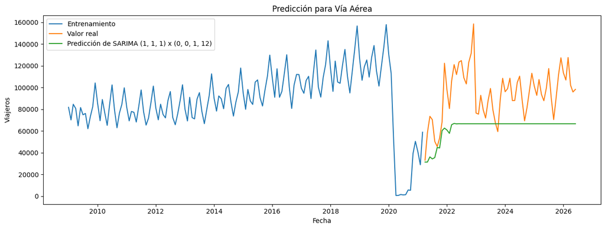

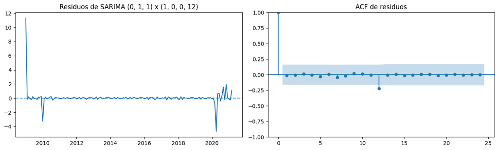

|  | lb_stat | lb_pvalue |
| --- | --- | --- |
| 12 | 8.449 | 0.749 |

```
No se detecta autocorrelación importante en los residuos al nivel de cinco por ciento.
==========================================================================================
Vía Terrestre
==========================================================================================
Comparación de modelos SARIMA
```

|  | Modelo | MAE | RMSE | AIC | BIC |
| --- | --- | --- | --- | --- | --- |
| 0 | SARIMA (0, 1, 1) x (1, 0, 0, 12) | 141,003.527 | 152,850.854 | 112.787 | 121.481 |
| 1 | SARIMA (1, 1, 1) x (1, 0, 0, 12) | 141,488.036 | 153,326.451 | 114.507 | 126.069 |
| 2 | SARIMA (1, 1, 1) x (0, 0, 1, 12) | 129,885.387 | 141,867.983 | 123.435 | 134.966 |
| 3 | SARIMA (2, 1, 1) x (0, 0, 1, 12) | 125,667.999 | 137,882.771 | 123.970 | 138.384 |
| 4 | SARIMA (1, 1, 2) x (0, 0, 1, 12) | 127,826.803 | 139,969.119 | 124.214 | 138.590 |

```
22:20:33 - cmdstanpy - INFO - Chain [1] start processing
22:20:33 - cmdstanpy - INFO - Chain [1] done processing
```

```
Comparación general
```

|  | Modelo | MAE | RMSE | AIC | BIC |
| --- | --- | --- | --- | --- | --- |
| 0 | Prophet | 47,712.983 | 57,657.637 | NaN | NaN |
| 1 | Suavizamiento exponencial simple | 121,715.510 | 134,136.097 | NaN | NaN |
| 2 | Holt Winters | 123,748.611 | 134,151.113 | NaN | NaN |
| 3 | SARIMA (2, 1, 1) x (0, 0, 1, 12) | 125,667.999 | 137,882.771 | 123.970 | 138.384 |
| 4 | SARIMA (1, 1, 2) x (0, 0, 1, 12) | 127,826.803 | 139,969.119 | 124.214 | 138.590 |
| 5 | SARIMA (1, 1, 1) x (0, 0, 1, 12) | 129,885.387 | 141,867.983 | 123.435 | 134.966 |
| 6 | Seasonal naive | 132,209.038 | 144,274.981 | NaN | NaN |
| 7 | SARIMA (0, 1, 1) x (1, 0, 0, 12) | 141,003.527 | 152,850.854 | 112.787 | 121.481 |
| 8 | SARIMA (1, 1, 1) x (1, 0, 0, 12) | 141,488.036 | 153,326.451 | 114.507 | 126.069 |

```
Mejor SARIMA según AIC y BIC: SARIMA (0, 1, 1) x (1, 0, 0, 12)
Mejor modelo según RMSE: Prophet
```

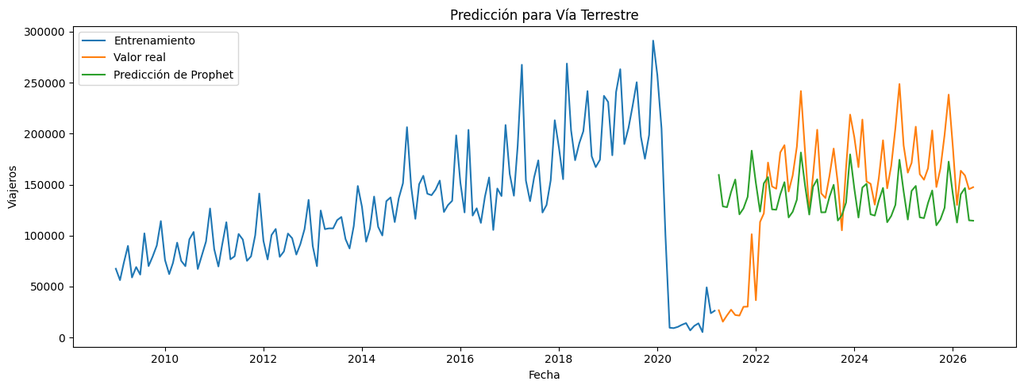

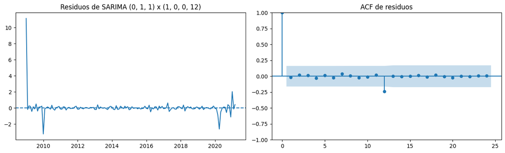

|  | lb_stat | lb_pvalue |
| --- | --- | --- |
| 12 | 10.199 | 0.599 |

```
No se detecta autocorrelación importante en los residuos al nivel de cinco por ciento.
==========================================================================================
Vía Marítima
==========================================================================================
Comparación de modelos SARIMA
```

|  | Modelo | MAE | RMSE | AIC | BIC |
| --- | --- | --- | --- | --- | --- |
| 0 | SARIMA (0, 1, 1) x (1, 0, 0, 12) | 0.000 | 0.000 | 257.751 | 266.445 |
| 1 | SARIMA (1, 1, 1) x (0, 0, 1, 12) | 0.000 | 0.000 | 257.839 | 269.370 |
| 2 | SARIMA (1, 1, 1) x (1, 0, 0, 12) | 0.000 | 0.000 | 258.813 | 270.375 |
| 3 | SARIMA (1, 1, 2) x (0, 0, 1, 12) | 0.000 | 0.000 | 258.834 | 273.210 |
| 4 | SARIMA (2, 1, 1) x (0, 0, 1, 12) | 0.000 | 0.000 | 259.700 | 274.114 |

```
22:20:34 - cmdstanpy - INFO - Chain [1] start processing
22:20:34 - cmdstanpy - INFO - Chain [1] done processing
```

```
Comparación general
```

|  | Modelo | MAE | RMSE | AIC | BIC |
| --- | --- | --- | --- | --- | --- |
| 0 | SARIMA (0, 1, 1) x (1, 0, 0, 12) | 0.000 | 0.000 | 257.751 | 266.445 |
| 1 | SARIMA (1, 1, 1) x (1, 0, 0, 12) | 0.000 | 0.000 | 258.813 | 270.375 |
| 2 | Seasonal naive | 0.000 | 0.000 | NaN | NaN |
| 3 | Prophet | 0.000 | 0.000 | NaN | NaN |
| 4 | Suavizamiento exponencial simple | 0.000 | 0.000 | NaN | NaN |
| 5 | SARIMA (2, 1, 1) x (0, 0, 1, 12) | 0.000 | 0.000 | 259.700 | 274.114 |
| 6 | SARIMA (1, 1, 2) x (0, 0, 1, 12) | 0.000 | 0.000 | 258.834 | 273.210 |
| 7 | SARIMA (1, 1, 1) x (0, 0, 1, 12) | 0.000 | 0.000 | 257.839 | 269.370 |
| 8 | Holt Winters | 2.091 | 10.767 | NaN | NaN |

```
Mejor SARIMA según AIC y BIC: SARIMA (0, 1, 1) x (1, 0, 0, 12)
Mejor modelo según RMSE: SARIMA (0, 1, 1) x (1, 0, 0, 12)
```

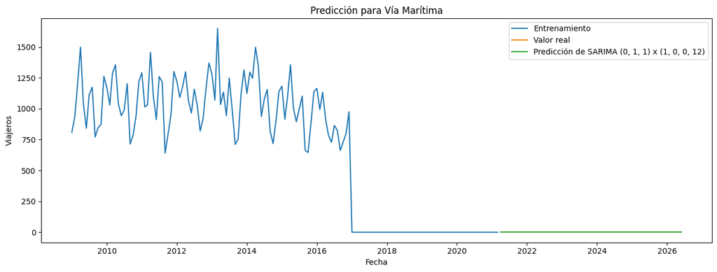

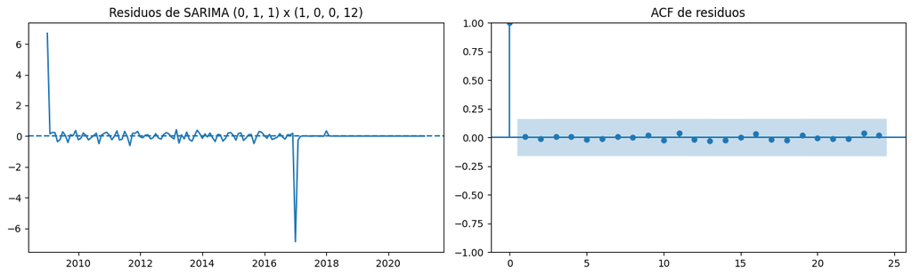

|  | lb_stat | lb_pvalue |
| --- | --- | --- |
| 12 | 0.579 | 1.000 |

```
No se detecta autocorrelación importante en los residuos al nivel de cinco por ciento.
==========================================================================================
Región América Del Centro
==========================================================================================
Comparación de modelos SARIMA
```

|  | Modelo | MAE | RMSE | AIC | BIC |
| --- | --- | --- | --- | --- | --- |
| 0 | SARIMA (0, 1, 1) x (1, 0, 0, 12) | 139,836.336 | 149,828.557 | 64.362 | 73.056 |
| 1 | SARIMA (2, 1, 2) x (1, 0, 0, 12) | 141,082.044 | 151,051.773 | 69.794 | 87.091 |
| 2 | SARIMA (2, 1, 2) x (0, 0, 1, 12) | 121,084.093 | 132,185.470 | 72.607 | 89.858 |
| 3 | SARIMA (1, 1, 1) x (0, 0, 1, 12) | 115,353.637 | 125,991.096 | 79.553 | 91.084 |
| 4 | SARIMA (2, 1, 1) x (0, 0, 1, 12) | 115,368.273 | 126,147.680 | 80.474 | 94.888 |
| 5 | SARIMA (1, 1, 2) x (0, 0, 1, 12) | 114,754.813 | 125,560.746 | 80.704 | 95.080 |

```
22:20:35 - cmdstanpy - INFO - Chain [1] start processing
22:20:35 - cmdstanpy - INFO - Chain [1] done processing
```

```
Comparación general
```

|  | Modelo | MAE | RMSE | AIC | BIC |
| --- | --- | --- | --- | --- | --- |
| 0 | Prophet | 62,484.796 | 67,837.611 | NaN | NaN |
| 1 | Suavizamiento exponencial simple | 109,866.650 | 121,961.448 | NaN | NaN |
| 2 | SARIMA (1, 1, 2) x (0, 0, 1, 12) | 114,754.813 | 125,560.746 | 80.704 | 95.080 |
| 3 | SARIMA (1, 1, 1) x (0, 0, 1, 12) | 115,353.637 | 125,991.096 | 79.553 | 91.084 |
| 4 | SARIMA (2, 1, 1) x (0, 0, 1, 12) | 115,368.273 | 126,147.680 | 80.474 | 94.888 |
| 5 | SARIMA (2, 1, 2) x (0, 0, 1, 12) | 121,084.093 | 132,185.470 | 72.607 | 89.858 |
| 6 | Seasonal naive | 134,400.175 | 144,899.303 | NaN | NaN |
| 7 | SARIMA (0, 1, 1) x (1, 0, 0, 12) | 139,836.336 | 149,828.557 | 64.362 | 73.056 |
| 8 | SARIMA (2, 1, 2) x (1, 0, 0, 12) | 141,082.044 | 151,051.773 | 69.794 | 87.091 |
| 9 | Holt Winters | 149,160.999 | 160,928.551 | NaN | NaN |

```
Mejor SARIMA según AIC y BIC: SARIMA (0, 1, 1) x (1, 0, 0, 12)
Mejor modelo según RMSE: Prophet
```

[figure not shown]

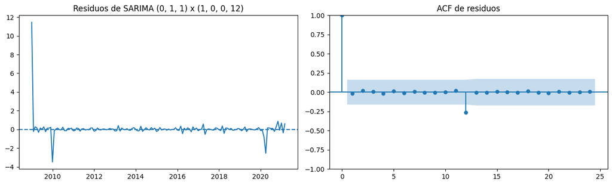

|  | lb_stat | lb_pvalue |
| --- | --- | --- |
| 12 | 11.406 | 0.494 |

```
No se detecta autocorrelación importante en los residuos al nivel de cinco por ciento.
==========================================================================================
Región América Del Norte
==========================================================================================
Comparación de modelos SARIMA
```

|  | Modelo | MAE | RMSE | AIC | BIC |
| --- | --- | --- | --- | --- | --- |
| 0 | SARIMA (1, 1, 2) x (0, 0, 1, 12) | 38,116.430 | 42,152.886 | 405.541 | 419.917 |
| 1 | SARIMA (2, 1, 1) x (0, 0, 1, 12) | 37,721.449 | 41,879.093 | 408.455 | 422.869 |
| 2 | SARIMA (1, 1, 1) x (0, 0, 1, 12) | 28,764.645 | 32,925.075 | 411.604 | 423.135 |
| 3 | SARIMA (1, 1, 1) x (1, 0, 0, 12) | 34,508.521 | 38,124.795 | 411.925 | 423.486 |
| 4 | SARIMA (0, 1, 1) x (1, 0, 0, 12) | 37,052.427 | 40,493.577 | 412.280 | 420.974 |

```
22:20:36 - cmdstanpy - INFO - Chain [1] start processing
22:20:36 - cmdstanpy - INFO - Chain [1] done processing
```

```
Comparación general
```

|  | Modelo | MAE | RMSE | AIC | BIC |
| --- | --- | --- | --- | --- | --- |
| 0 | SARIMA (1, 1, 1) x (0, 0, 1, 12) | 28,764.645 | 32,925.075 | 411.604 | 423.135 |
| 1 | SARIMA (1, 1, 1) x (1, 0, 0, 12) | 34,508.521 | 38,124.795 | 411.925 | 423.486 |
| 2 | SARIMA (0, 1, 1) x (1, 0, 0, 12) | 37,052.427 | 40,493.577 | 412.280 | 420.974 |
| 3 | SARIMA (2, 1, 1) x (0, 0, 1, 12) | 37,721.449 | 41,879.093 | 408.455 | 422.869 |
| 4 | SARIMA (1, 1, 2) x (0, 0, 1, 12) | 38,116.430 | 42,152.886 | 405.541 | 419.917 |
| 5 | Prophet | 39,112.832 | 44,175.902 | NaN | NaN |
| 6 | Suavizamiento exponencial simple | 39,603.739 | 44,300.517 | NaN | NaN |
| 7 | Seasonal naive | 49,974.108 | 53,533.367 | NaN | NaN |
| 8 | Holt Winters | 49,534.801 | 54,187.694 | NaN | NaN |

```
Mejor SARIMA según AIC y BIC: SARIMA (1, 1, 2) x (0, 0, 1, 12)
Mejor modelo según RMSE: SARIMA (1, 1, 1) x (0, 0, 1, 12)
```

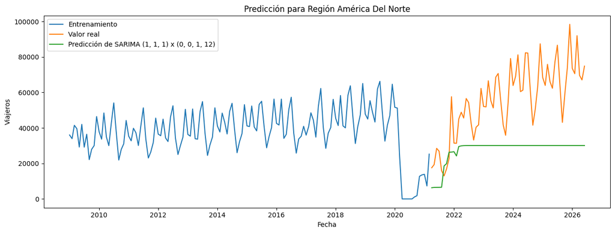

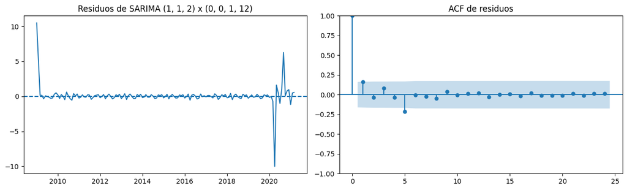

|  | lb_stat | lb_pvalue |
| --- | --- | --- |
| 12 | 13.201 | 0.355 |

```
No se detecta autocorrelación importante en los residuos al nivel de cinco por ciento.
==========================================================================================
Región Europa
==========================================================================================
Comparación de modelos SARIMA
```

|  | Modelo | MAE | RMSE | AIC | BIC |
| --- | --- | --- | --- | --- | --- |
| 0 | SARIMA (2, 1, 1) x (0, 0, 1, 12) | 9,396.071 | 10,642.486 | 341.750 | 356.164 |
| 1 | SARIMA (0, 1, 1) x (1, 0, 0, 12) | 11,303.780 | 12,449.437 | 342.698 | 351.391 |
| 2 | SARIMA (1, 1, 1) x (1, 0, 0, 12) | 11,239.973 | 12,374.658 | 343.013 | 354.574 |
| 3 | SARIMA (1, 1, 1) x (0, 0, 1, 12) | 9,153.821 | 10,394.796 | 347.088 | 358.619 |
| 4 | SARIMA (1, 1, 2) x (0, 0, 1, 12) | 9,262.626 | 10,502.724 | 347.491 | 361.867 |

```
22:20:37 - cmdstanpy - INFO - Chain [1] start processing
22:20:37 - cmdstanpy - INFO - Chain [1] done processing
```

```
Comparación general
```

|  | Modelo | MAE | RMSE | AIC | BIC |
| --- | --- | --- | --- | --- | --- |
| 0 | SARIMA (1, 1, 1) x (0, 0, 1, 12) | 9,153.821 | 10,394.796 | 347.088 | 358.619 |
| 1 | SARIMA (1, 1, 2) x (0, 0, 1, 12) | 9,262.626 | 10,502.724 | 347.491 | 361.867 |
| 2 | SARIMA (2, 1, 1) x (0, 0, 1, 12) | 9,396.071 | 10,642.486 | 341.750 | 356.164 |
| 3 | Suavizamiento exponencial simple | 9,571.367 | 10,978.122 | NaN | NaN |
| 4 | Prophet | 10,118.838 | 11,538.135 | NaN | NaN |
| 5 | Seasonal naive | 11,075.465 | 12,134.507 | NaN | NaN |
| 6 | SARIMA (1, 1, 1) x (1, 0, 0, 12) | 11,239.973 | 12,374.658 | 343.013 | 354.574 |
| 7 | SARIMA (0, 1, 1) x (1, 0, 0, 12) | 11,303.780 | 12,449.437 | 342.698 | 351.391 |
| 8 | Holt Winters | 11,507.563 | 12,765.099 | NaN | NaN |

```
Mejor SARIMA según AIC y BIC: SARIMA (2, 1, 1) x (0, 0, 1, 12)
Mejor modelo según RMSE: SARIMA (1, 1, 1) x (0, 0, 1, 12)
```

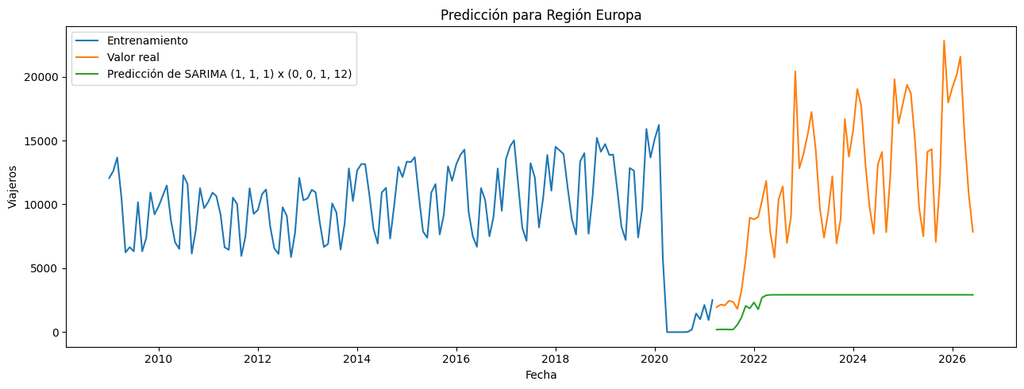

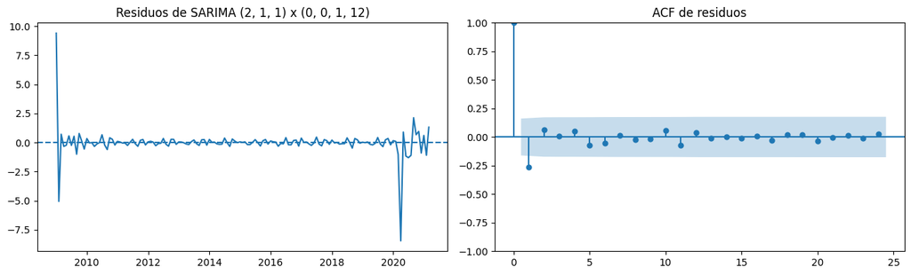

|  | lb_stat | lb_pvalue |
| --- | --- | --- |
| 12 | 14.487 | 0.271 |

```
No se detecta autocorrelación importante en los residuos al nivel de cinco por ciento.
```

| Serie | Mejor modelo | MAE | RMSE | Mejor SARIMA | AIC mejor SARIMA | BIC mejor SARIMA | p valor Ljung Box |
| --- | --- | --- | --- | --- | --- | --- | --- |
| Total | Prophet | 132,304.568 | 139,548.877 | SARIMA (0, 1, 1) x (1, 0, 0, 12) | 77.161 | 85.854 | 0.624 |
| Vía Aérea | SARIMA (1, 1, 1) x (0, 0, 1, 12) | 31,483.389 | 36,548.987 | SARIMA (0, 1, 1) x (1, 0, 0, 12) | 196.900 | 205.593 | 0.749 |
| Vía Terrestre | Prophet | 47,712.983 | 57,657.637 | SARIMA (0, 1, 1) x (1, 0, 0, 12) | 112.787 | 121.481 | 0.599 |
| Vía Marítima | SARIMA (0, 1, 1) x (1, 0, 0, 12) | 0.000 | 0.000 | SARIMA (0, 1, 1) x (1, 0, 0, 12) | 257.751 | 266.445 | 1.000 |
| Región América Del Centro | Prophet | 62,484.796 | 67,837.611 | SARIMA (0, 1, 1) x (1, 0, 0, 12) | 64.362 | 73.056 | 0.494 |
| Región América Del Norte | SARIMA (1, 1, 1) x (0, 0, 1, 12) | 28,764.645 | 32,925.075 | SARIMA (1, 1, 2) x (0, 0, 1, 12) | 405.541 | 419.917 | 0.355 |
| Región Europa | SARIMA (1, 1, 1) x (0, 0, 1, 12) | 9,153.821 | 10,394.796 | SARIMA (2, 1, 1) x (0, 0, 1, 12) | 341.750 | 356.164 | 0.271 |

# Análisis comparativo

La estacionalidad se mide con la proporción de variación explicada por el componente estacional. La tendencia se resume con el cambio anual aproximado del logaritmo de la serie. La volatilidad se compara con el coeficiente de variación. El efecto de la pandemia se calcula con el cambio de 2020 frente a 2019.

| Serie | Fuerza estacional | Crecimiento anual aproximado | Coeficiente de variación | Cambio 2020 frente a 2019 |
| --- | --- | --- | --- | --- |
| Total | 0.256 | 1.283 | 0.381 | -74.354 |
| Vía Aérea | 0.163 | -0.465 | 0.308 | -72.797 |
| Vía Terrestre | 0.230 | 2.130 | 0.463 | -75.225 |
| Vía Marítima | 0.051 | -44.653 | 1.134 | NaN |
| Región América Del Centro | 0.263 | 1.135 | 0.419 | -74.431 |
| Región América Del Norte | 0.083 | -0.135 | 0.410 | -74.144 |
| Región Europa | 0.211 | -1.957 | 0.430 | -71.830 |

```
Mayor estacionalidad: Región América Del Centro
Mayor tendencia de crecimiento: Vía Terrestre
Mayor volatilidad: Vía Marítima
Mayor caída durante la pandemia: Vía Terrestre
```

# Descubrimientos útiles para INGUAT

Los siguientes mensajes se generan con los resultados del análisis.

```
La vía con mayor volumen acumulado es Terrestre. Esto ayuda a priorizar personal, infraestructura y campañas en los puntos relacionados con esa vía.
La región que más viajeros aporta es América Del Centro. Puede considerarse como un mercado principal para promoción turística.
El mes con el componente estacional más alto en la serie total es diciembre. Conviene preparar capacidad antes de ese mes.
La serie más afectada por la pandemia fue Vía Terrestre. Esta serie necesita planes de recuperación y seguimiento especial.
Los modelos con menor RMSE pueden utilizarse para planificar personal, transporte, atención y campañas con varios meses de anticipación.
```

# Conclusiones

La transformación logarítmica ayuda a estabilizar la varianza. La prueba Dickey Fuller, la ACF y la PACF permiten definir las diferencias y los parámetros iniciales de los modelos SARIMA.

La selección final se realiza con las métricas del conjunto de prueba. El RMSE penaliza con mayor fuerza los errores grandes y el MAE muestra el error promedio en viajeros. AIC y BIC se utilizan para comparar únicamente los modelos SARIMA.

Las conclusiones finales deben leerse junto con las tablas generadas porque el mejor modelo puede ser diferente para cada serie.

# Archivos generados

Las figuras y tablas se guardan en data/processed/

```
Archivos generados
data\processed\.gitkeep
data\processed\figures\01_boxplot_viajero.png
data\processed\figures\02_total_mensual.png
data\processed\figures\03_total_anual.png
data\processed\figures\04_top_paises.png
data\processed\figures\05_top_regiones.png
data\processed\figures\06_vias_ingreso.png
data\processed\figures\07_top_fronteras.png
data\processed\figures\acf_pacf_región_america_del_centro.png
data\processed\figures\acf_pacf_región_america_del_norte.png
data\processed\figures\acf_pacf_región_europa.png
data\processed\figures\acf_pacf_total.png
data\processed\figures\acf_pacf_via_aerea.png
data\processed\figures\acf_pacf_via_maritima.png
data\processed\figures\acf_pacf_via_terrestre.png
data\processed\figures\descomposicion_región_america_del_centro.png
data\processed\figures\descomposicion_región_america_del_norte.png
data\processed\figures\descomposicion_región_europa.png
data\processed\figures\descomposicion_total.png
data\processed\figures\descomposicion_via_aerea.png
data\processed\figures\descomposicion_via_maritima.png
data\processed\figures\descomposicion_via_terrestre.png
data\processed\figures\prediccion_región_america_del_centro.png
data\processed\figures\prediccion_región_america_del_norte.png
data\processed\figures\prediccion_región_europa.png
data\processed\figures\prediccion_total.png
data\processed\figures\prediccion_via_aerea.png
data\processed\figures\prediccion_via_maritima.png
data\processed\figures\prediccion_via_terrestre.png
data\processed\figures\serie_región_america_del_centro.png
data\processed\figures\serie_región_america_del_norte.png
data\processed\figures\serie_región_europa.png
data\processed\figures\serie_total.png
data\processed\figures\serie_via_aerea.png
data\processed\figures\serie_via_maritima.png
data\processed\figures\serie_via_terrestre.png
data\processed\tables\analisis_comparativo.csv
data\processed\tables\diagnostico_series.csv
data\processed\tables\estadisticas_viajero.csv
data\processed\tables\modelos_región_america_del_centro.csv
data\processed\tables\modelos_región_america_del_norte.csv
data\processed\tables\modelos_región_europa.csv
data\processed\tables\modelos_total.csv
data\processed\tables\modelos_via_aerea.csv
data\processed\tables\modelos_via_maritima.csv
data\processed\tables\modelos_via_terrestre.csv
data\processed\tables\resumen_calidad.csv
data\processed\tables\resumen_modelos.csv
data\processed\tables\resumen_series.csv
data\processed\tables\series_mensuales.csv
data\processed\tables\top_fronteras.csv
data\processed\tables\top_paises.csv
data\processed\tables\top_regiones.csv
data\processed\tables\top_vias.csv
```